# Statistical Inference Project Part 1

Jing Wei Chan

23 August 2015

## Overview

In this project, we will investigate the exponential distribution in R and compare it with the Central Limit Theorem. The exponential distribution can be simulated in R with rexp(n, lambda) where lambda is the rate parameter. The mean of exponential distribution is 1/lambda and the standard deviation is also 1/lambda. lambda is set to 0.2 for all of the simulations. The distribution of averages of 40 exponentials will be investigated and a thousand simulations will be performed.

## Simulations

We will first run 1000 simulations of 40 exponentials each and get the average of these 1000 simulations. These 1000 simulations will be stored in a matrix.

```r
## Initialize values
set.seed(1)
lambda <- 0.2
sample_size <- 40
simulations <- 1000

## create a matrix with 1000 simulations of 40 exponentials each
sim <- matrix(rexp(simulations *  sample_size, rate = lambda), simulations)

## get the mean for the 1000 simulations
sim_mean <- rowMeans(sim)
```

## Sample Mean versus Theoretical Mean

Let us first calculate the sample mean.

```r
sample_mean <- round(mean(sim_mean),3)
```

The sample mean is 4.99.

Next, we calculate the theoretical mean, 1/lambda.

```r
theoretical_mean <- 1/lambda
```

The theoretical mean is 5.

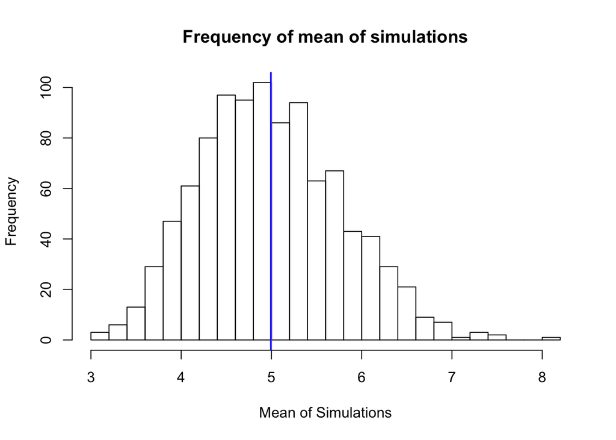

```r
hist(sim_mean,
     breaks = 20,
     xlab = "Mean of Simulations",
     ylab = "Frequency",
     main = "Frequency of mean of simulations")
abline(v = sample_mean, col = "blue")
abline(v = theoretical_mean, col = "red")
```

As shown in the diagram above, the sample mean 4.99 (in blue) is very close to the theoretical mean 5 (in red). The colour shown is in purple as the lines are very close to one another.

## Sample Variance versus Theoretical Variance

Let us first calculate the sample variance.

```r
sample_variance <- round(var(sim_mean),3)
```

```r
theoretical_variance <- (1/lambda)^2 * (1/sample_size)
```

Hence, we can see that the sample variance 0.618 is very close to the theoretical variance 0.625.

## Distribution

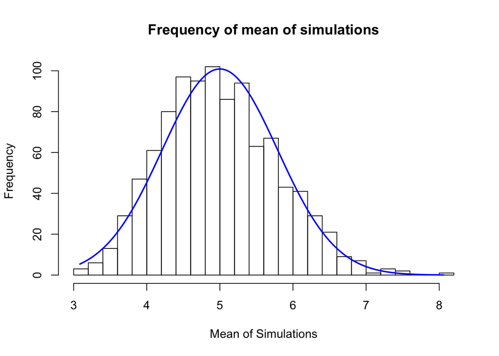

```r
h <- hist(sim_mean,
          breaks = 20,
          xlab = "Mean of Simulations",
          ylab = "Frequency",
          main = "Frequency of mean of simulations")
xfit <- seq(min(sim_mean), max(sim_mean), length = 100)
yfit <- dnorm(xfit, theoretical_mean, sqrt(theoretical_variance))
yfit <- yfit * diff(h$mids[1:2]) * length(sim_mean)
lines(xfit, yfit, col="blue", lwd=2)
```

As shown in the diagram, the distribution is approximately normal as shown by the normal distribution curve in blue.